# Practical N: Solutions

Gerko Vink, Laurence Frank

Statistical Programming in R

We use the following packages:

```r
library(boot)
library(mice)
library(dplyr)
library(magrittr)
library(ggplot2)
```

I fix the random seed to `123`

```r
set.seed(123)
```

1. **Use the following function to calculate the bootstrapped estimate for the correlation between `age` and `weight` on the `boys` data set. Use `R=1000` bootstrap samples.**

```r
corfun <- function(data, i){
  data.sample <- data[i,]
  stat <- cor(data.sample$age, data.sample$wgt, use = "pairwise.complete.obs")
    return(stat)
}
```

To apply the `corfun()` function in the bootstrap function `boot()`, we run:

```r
bootstr.cor <-
  boys %>%
  boot(corfun, R = 1000)
```

Our object `bootstr.cor` contains all the bootstrap information about the correlation parameter

2. **Explore the contents of the `bootstr.cor` object. For example, use function `attributes()` to see the listed dimensions that are within the `bootstr.cor` object and the `class` of the object.**

```r
attributes(bootstr.cor)
```

```
## $names
##  [1] "t0"        "t"         "R"         "data"      "seed"      "statistic"
##  [7] "sim"       "call"      "stype"     "strata"    "weights"
##
## $class
## [1] "boot"
##
## $boot_type
## [1] "boot"
```

we see that the `bootstr.cor` object has class `boot`.

```r
head(bootstr.cor$data)
```

```
##      age  hgt   wgt   bmi   hc  gen  phb tv   reg
## 3  0.035 50.1 3.650 14.54 33.7 <NA> <NA> NA south
## 4  0.038 53.5 3.370 11.77 35.0 <NA> <NA> NA south
## 18 0.057 50.0 3.140 12.56 35.2 <NA> <NA> NA south
## 23 0.060 54.5 4.270 14.37 36.7 <NA> <NA> NA south
## 28 0.062 57.5 5.030 15.21 37.3 <NA> <NA> NA south
## 36 0.068 55.5 4.655 15.11 37.0 <NA> <NA> NA south
```

The most interesting listed dimensions are the following:

- The `$t0` contains the original estimate for the data

```r
bootstr.cor$t0
```

```
## [1] 0.9505762
```

- The `$t` contains the individual estimate for every bootstrapped sample

```r
head(bootstr.cor$t)
```

```
##           [,1]
## [1,] 0.9532544
## [2,] 0.9494370
## [3,] 0.9527242
## [4,] 0.9511808
## [5,] 0.9521278
## [6,] 0.9531920
```

The average bootstrapped estimate would then be

```r
bootstr.cor$t %>% mean
```

```
## [1] 0.9507738
```

- The `$data` has the original data set that has been served to function `boot()`:

```r
head(bootstr.cor$data)
```

```
##      age  hgt   wgt   bmi   hc  gen  phb tv   reg
## 3  0.035 50.1 3.650 14.54 33.7 <NA> <NA> NA south
## 4  0.038 53.5 3.370 11.77 35.0 <NA> <NA> NA south
## 18 0.057 50.0 3.140 12.56 35.2 <NA> <NA> NA south
## 23 0.060 54.5 4.270 14.37 36.7 <NA> <NA> NA south
## 28 0.062 57.5 5.030 15.21 37.3 <NA> <NA> NA south
## 36 0.068 55.5 4.655 15.11 37.0 <NA> <NA> NA south
```

3. **Plot the histogram of the individual bootstrapped estimates for every bootstrapped sample (i.e. `$t`).**

[figure not shown]

```r
plotdata <- data.frame(t = bootstr.cor$t)

plotdata %>%
  ggplot(aes(t)) +
  geom_histogram(bins = 20) +
  geom_density(col = "orange") +
  geom_vline(xintercept = bootstr.cor$t0, col = "orange", linetype = "dashed", linewidth = 1.5)
```

4. **Add a column to boys that indicates whether boys are overweight by taking the boundary `bmi > 25`.**

Remember that body mass index takes the ratio weight-over-height-squared into account and the validity of the interpretation does change for children vs. adults.

We can use function `mutate()` to assign values to a new column (variable) `ovw` for boys that have a `bmi <= 25` (smaller or equal) or `bmi > 25` (larger). The `if_else()` function can be directly applied to call `if_else(condition, true, false)`.

```r
boys2 <- boys %>%
    mutate(ovw = if_else(bmi <= 25, "Not Overweight", "Overweight"))
```

There are now 20 `Overweight` boys:

```r
boys2 %$%
  table(ovw)
```

```
## ovw
## Not Overweight     Overweight
##            707             20
```

5. **Bootstrap a $X^2$-test that evaluates the distribution of overweight `ovw` boys over the regions `reg`.** We can copy the previous function and replace the line for our test-statistic:

```r
X2fun <- function(data, i){
  data.sample <- data[i,]
  tab <- data.sample %$%
    table(ovw, reg)
  X2 <- suppressWarnings(chisq.test(tab))
    return(X2$statistic)
}
```

I use `suppressWarnings()` to suppress the warnings the $X^2$ test is going to give us, because some of the expected cell-frequencies are below 5. I only return the chi-squared estimate by asking for `X2$statistic`. This is because function `boot` expects an estimate as return, not a whole list of estimates.

```r
bootstr.X2 <-
  boys2 %>%
  boot(X2fun, R = 1000)

bootstr.X2
```

```
##
## ORDINARY NONPARAMETRIC BOOTSTRAP
##
##
## Call:
## boot(data = ., statistic = X2fun, R = 1000)
##
##
## Bootstrap Statistics :
##     original   bias    std. error
## t1* 3.650944 3.775064    4.895331
```

6. **Plot the histogram of the individual bootstrapped estimates for every bootstrapped sample (i.e. `$t`).**

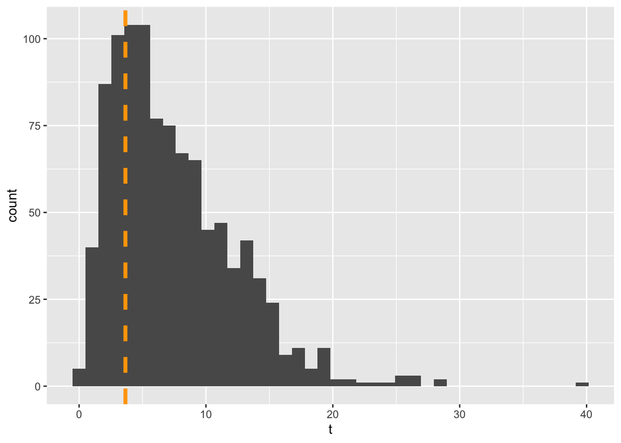

```r
plotdata <- data.frame(t = bootstr.X2$t)

plotdata %>%
  ggplot(aes(t)) +
  geom_histogram(bins = 40) +
  geom_vline(xintercept = bootstr.X2$t0, col = "orange", linetype = "dashed", linewidth = 1.5)
```

The sampling distribution of the estimate is quite skewed.

7. **Do a bootstrap of the regression estimates of the following model:**
- `lm(wgt ~ age + hgt + I(hgt^2))`

The function that would give us the regression estimates for the parameters is e.g. :

```r
lmfun <- function(data, i){
  data.sample <- data[i,]
  coef <- data.sample %$%
    lm(wgt ~ age + hgt + I(hgt^2)) %>%
    coef()
    return(coef)
}
```

and if we plug that function into `boot()` for `R = 1000` bootstrap samples, we obtain

```r
bootstr.lm <-
  boys %>%
  boot(lmfun, R = 1000)

bootstr.lm
```

```
##
## ORDINARY NONPARAMETRIC BOOTSTRAP
##
##
## Call:
## boot(data = ., statistic = lmfun, R = 1000)
##
##
## Bootstrap Statistics :
##         original        bias     std. error
## t1* 23.853118370  1.453609e-02 1.9359294811
## t2*  0.710865240 -2.103321e-03 0.2403071014
## t3* -0.498229914  1.175075e-04 0.0380706182
## t4*  0.003722907 -9.715547e-07 0.0002249442
```

Again, the observed data regression estimate is:

```r
bootstr.lm$t0
```

```
##  (Intercept)          age          hgt     I(hgt^2)
## 23.853118370  0.710865240 -0.498229914  0.003722907
```

8. **Create a histogram of the individual bootstrapped estimates** There are two ways to do this.
9. Using the plot options of the class `boot`.
10. Construct the plots manually by extracting the regression coefficients from the boot class object.

Plot the distribution of the intercept by using the `index` argument (1 refers to the intercept and subsequent numbers to the remaining regression coefficients / slopes).

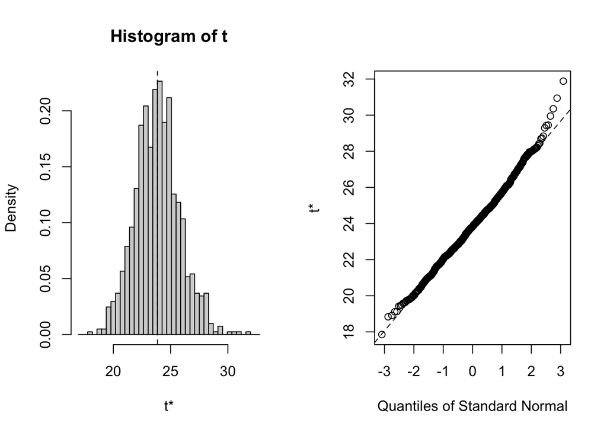

```r
plot(bootstr.lm, index = 1)
```

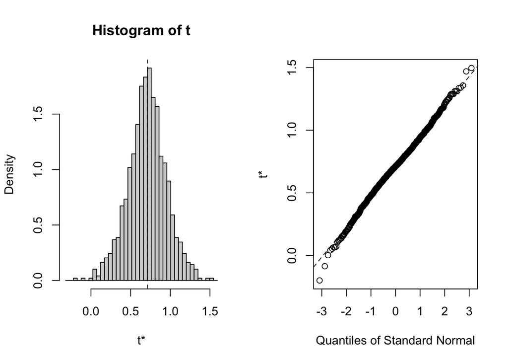

```r
plot(bootstr.lm, index = 2)
```

Plot the distribution of the slope of `hgt`:

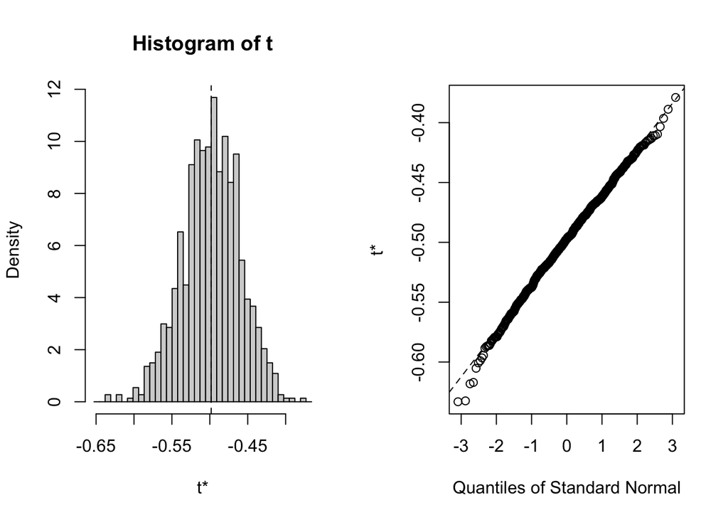

```r
plot(bootstr.lm, index = 3)
```

Plot the distribution of the slope of `hgt^2`:

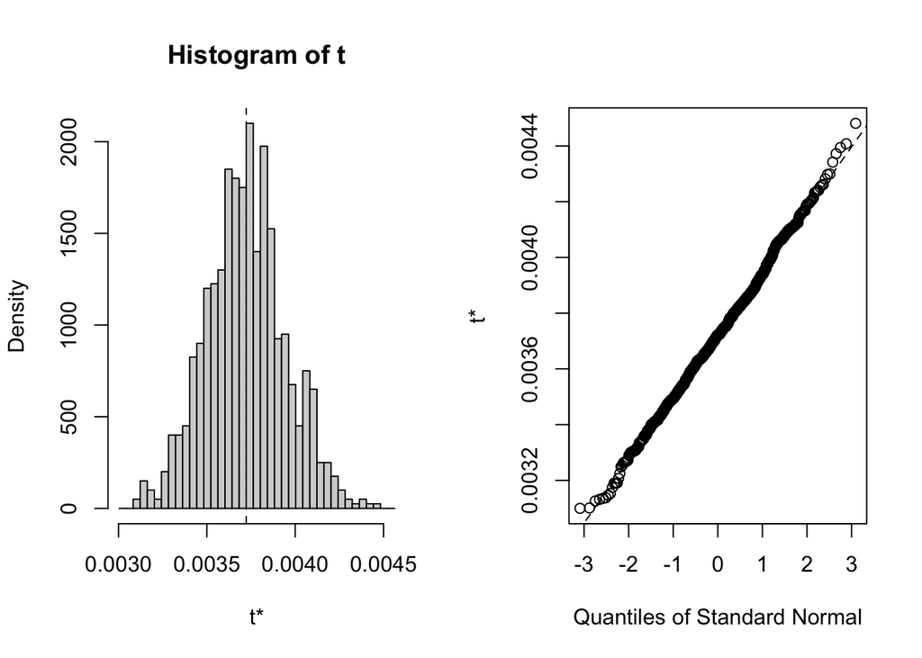

```r
plot(bootstr.lm, index = 4)
```

**Option 2: manually** Look at the code to see if you understand what it does.

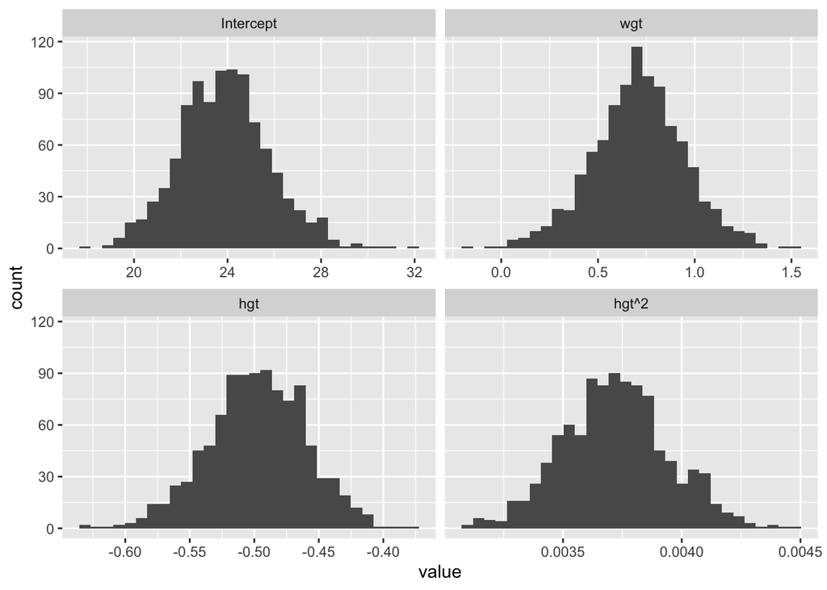

```r
est <- bootstr.lm$t
colnames(est) <- (c("Intercept", "wgt", "hgt", "hgt^2"))

reshape2::melt(est) %>%
  ggplot(aes(value)) + facet_wrap(~Var2, scales = 'free_x') +
  geom_histogram()
```

9. **Calculate the confidence intervals for the intercept and slopes**

We can use function `boot.ci()` to obtain the confidence intervals from our estimates. Remember that there we have 4 statistics: one intercept and three slopes. The bootstrap confidence interval of the intercept can be obtained with the argument `index = 1` and we choose the basic interval:

```r
boot.ci(bootstr.lm, type = "basic", index = 1)
```

```
## BOOTSTRAP CONFIDENCE INTERVAL CALCULATIONS
## Based on 1000 bootstrap replicates
##
## CALL :
## boot.ci(boot.out = bootstr.lm, type = "basic", index = 1)
##
## Intervals :
## Level      Basic
## 95%   (19.73, 27.57 )
## Calculations and Intervals on Original Scale
```

```r
boot.ci(bootstr.lm, type = "basic", index = 2)
```

```
## BOOTSTRAP CONFIDENCE INTERVAL CALCULATIONS
## Based on 1000 bootstrap replicates
##
## CALL :
## boot.ci(boot.out = bootstr.lm, type = "basic", index = 2)
##
## Intervals :
## Level      Basic
## 95%   ( 0.2376,  1.2161 )
## Calculations and Intervals on Original Scale
```

```r
boot.ci(bootstr.lm, type = "basic", index = 3)
```

```
## BOOTSTRAP CONFIDENCE INTERVAL CALCULATIONS
## Based on 1000 bootstrap replicates
##
## CALL :
## boot.ci(boot.out = bootstr.lm, type = "basic", index = 3)
##
## Intervals :
## Level      Basic
## 95%   (-0.5709, -0.4195 )
## Calculations and Intervals on Original Scale
```

```r
boot.ci(bootstr.lm, type = "basic", index = 4)
```

```
## BOOTSTRAP CONFIDENCE INTERVAL CALCULATIONS
## Based on 1000 bootstrap replicates
##
## CALL :
## boot.ci(boot.out = bootstr.lm, type = "basic", index = 4)
##
## Intervals :
## Level      Basic
## 95%   ( 0.0033,  0.0041 )
## Calculations and Intervals on Original Scale
```

We can also use the `quantiles()` for the `$t` dimensions. For example, to obtain the cut-offs for `.025` and `.975` from the empirical distribution for the intercept, use:

```r
quantile(est[, "Intercept"], c(0.025,0.975))
```

```
##     2.5%    97.5%
## 20.15042 27.96690
```

or, for all estimates when using `apply()`:

```r
apply(est, 2, function(x) quantile(x, c(0.025,0.975)))
```

```
##       Intercept       wgt        hgt       hgt^2
## 2.5%   20.15042 0.2116248 -0.5767418 0.003300655
## 97.5%  27.96690 1.1784080 -0.4262788 0.004167523
```

To calculate the percentile bootstrap CI by hand:

```r
sort(est[, "Intercept"])[c(25, 976)]
```

```
## [1] 20.13762 27.97504
```

End of Practical